# Data Exploration Project

Veng Leap Chan

2022-06-10

## Our Data Set

Our data set was provided by Kaggle, called the [“U.S. Minimum Wage by State from 1968 to 2020”](https://www.kaggle.com/datasets/lislejoem/us-minimum-wage-by-state-from-1968-to-2017). Our data set provided an insight into the federal, state, and effective minimum wages of different States through 1968 to 2020, in which, effective minimum wage describes the higher of federal or state minimum wage.

We intend to observe the change in the overall real minimum wage, in which, the real minimum wage is adjusted for inflation, the distribution of real minimum wages across the states, and other relationship between real and actual federal, state, and effective minimum wages.

The data for this dataset was collected by The United States Department of Labor. Though this data set was said to be clean, our team did more cleaning by looking for missing data as well as any discrepancies in our data set. Though our rigorous checks and scanning, we did not find any discrepancies and proceeded with our data.

The story we are trying to present is that coastal states tend to have higher real, effective minimum wages, as well as, minimum wage growth is losing to inflation growth, causing real money to lose its value compared the past. We will share our story through different graphs.

As economists we intent to help economic journalists who will want this information to write newspaper articles on economic news on the topic “U.S Minimum Wage by State from 1968 to 2020”. The graphs that we are going to show will give them a clearer understanding of the U.S minimum wages.

## Graph 1: State vs. Real Minimum Wage Over Time

[figure not shown]

In this graph, we describe a map of United States, outlining each state and Hawaii, in which we should the real, effective minimum wage in each state over the span of about 5 decades. The viewer of this graph has control over what year is being displayed. Moreover, through the use of our color, foster comparison between the states and their respective minimum wages as darker color indicates higher minimum wage. In addition to this, viewers can hover over each state and see the specific minimum wages if they prefer.

Through the use of our graph, viewers can understand what the distribution of real effective wages, the actual value of their minimum wages in terms of 2020 dollars, will be. Using this metric, we can see the growth or decline of real, minimum wage over time. We can also use this to delve deeper into specific states. As an economist writer, we can see that many states that are closer to the ocean tend to generally have higher minimum wages. We would want to do further research into understand the relationship between geographical location and minimum wage and see if cost of living is higher in those areas.

## Graph 2: Top 5 States with Higest Average Minimum Wage

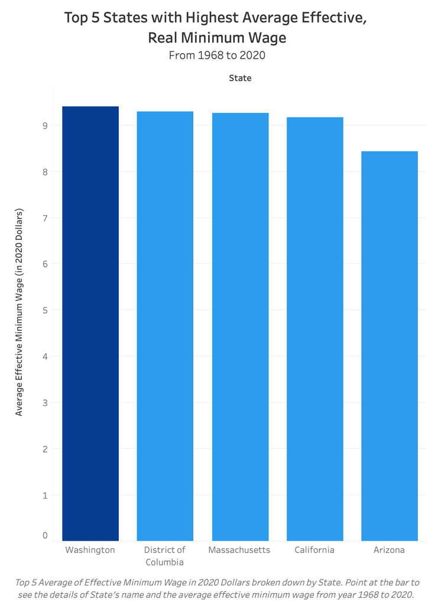

The graph shows the top 5 States that have the highest average effective real minimum wages in the United States from 1968 to 2020. Viewers can hover over each bar to see more detail about the state.

Firstly, we found the top 5 states that has the highest average effective, real minimum wages over the span of the 5 decades and explored the connection and relationship between the states and wages. We highlight Washington State since it has the highest minimum wage compared to other states.

There are 5 states: Washington, District of Columbia, Massachusetts, California, and Arizona. What those states have in common is they are on the coastal states, or is closer to the sea therefore which could see a relationship between geographical location and minimum wages. Through our exploration, assume that those states have more opportunities and more traffic due to them being hubs, thus increasing their average minimum wage.

Moreover, people can use this data to observe on which States that has the highest minimum wage in term if they want to move or seeking for jobs where they can earn more. On the Other hand, the government can use this data to implement the solution to increase the minimum wage in the other states as well. We would recommend increasing the minimum wage since the minimum wage would not cover all the expenses.

## Graph 3: Real and Actual Federal Minimum Wage

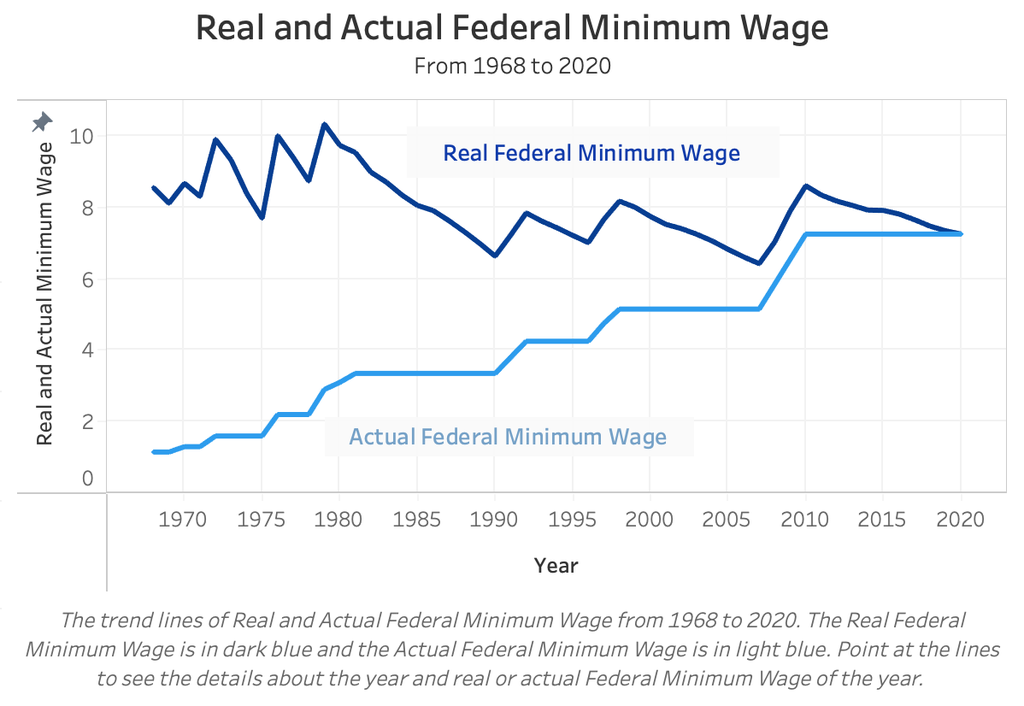

The line graph describes the real federal minimum wage and actual federal minimum wage between 1968 and 2020. The actual federal minimum wage reflects the minimum wage that employees will receive at a specific period. On the other hand, the real federal minimum wage helps people compare the minimum wage between years while taking the value changes in response to inflation into consideration.

We graphed our “Real and Actual Federal Minimum Wage” by using the original data points since the Federal minimum wage is constant for all states each year.

As econonomist, we urge the government to consider adjusting the minimum wage in order to ensure that minimum wage workers can make an effort to live in today’s economy.

## Graph 4: State and Federal Real, Average, Effective Minimum Wage

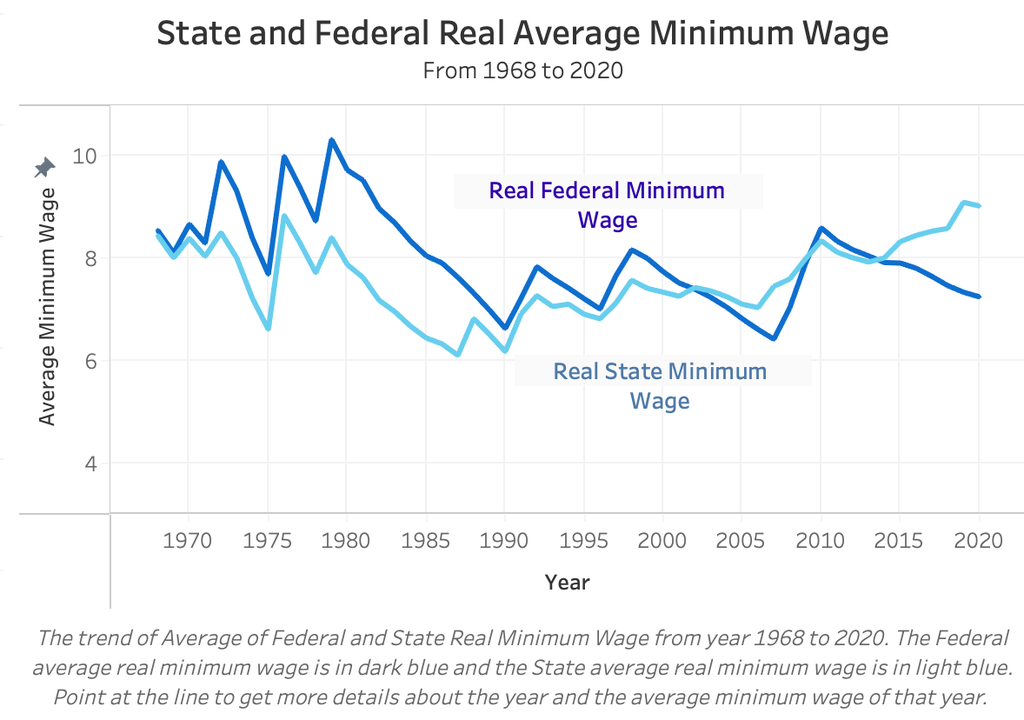

In this graph, we want to show the real minimum wage overtime in both state and federal levels, as real dollars (in terms of 2020 dollars) tell us the true value of wage because it strips out the effects of inflation. To get the clean data for this graph, we first filter out state minimum wage that is equal to or smaller than 0. For there were many states did not have a state minimum wage back in 1960-70 and including 0 in our data would lower the average minimum wage.

We suggest the government encourage state to reexamine their state minimum wage based on their state economy structures standard of living to see if minimum wage workers can afford to live with those wages in their state.

## Graph 5: Real Average Minimum Wage Change in (%) from 1968

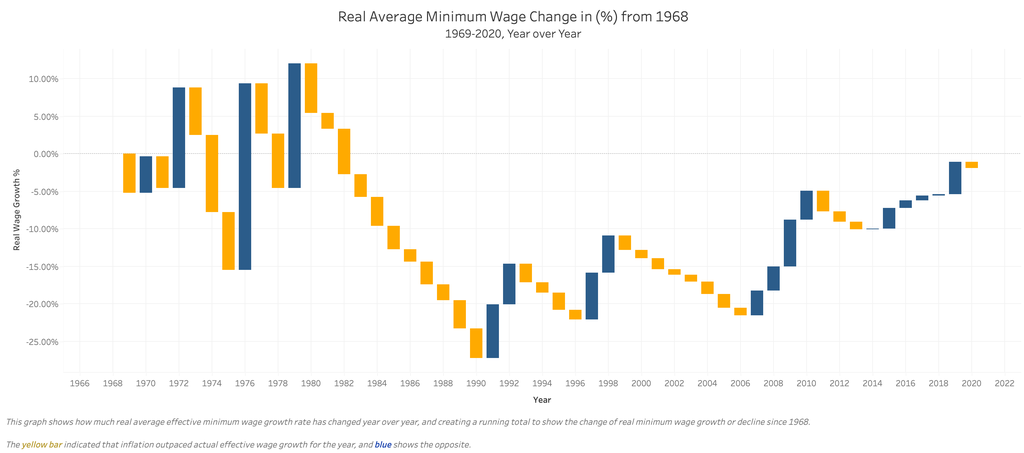

This Graph shows the Running Total of Real Minimum Wage Growth, Year over Year. Real Wage Growth meaning how much Minimum Wage has fallen or grown after accounting for inflation. In the toolkit the statistic that will show this will be the ‘Total Real Wage Growth since 1968’. This number represents the percentage difference between Minimum Wage and Inflation since the base year (1968). For example, the value for Total Real Wage Growth in 1979 is 11.98%, this means that since the base year, accounting for inflation, Minimum Wage is 11.98% higher than it was in 1968.

The Other value in the Toolkit is ‘(YoY) Real Wage Growth’. This Number represents how much the Total Real Wage Growth has changed from the year prior. Going back to 1979 we see the value was 16.54%, this means that compared to 1978, Total Real Wage Growth has increased by 16.54 percentage points, (-4.55% + 16.54% = 11.98%). Visualizing these two numbers, the Real Wage Growth is represented by where the top of the bar meets the % value on the Y-axis, and the YoY Growth is represented by the length of the bar. The bar is blue if YoY Growth is positive, and Orange if it is negative.